# Stats for genomics exercises

# 1 How to summarize collection of data points: The idea behind statistical distributions

## 1.1

Calculate the means and variances of the rows of the following simulated data set, plot the distributions of means and variances using `hist()` and `boxplot()` functions.

```r
set.seed(100)

#sample data matrix from normal distribution
gset=rnorm(600,mean=200,sd=70)
data=matrix(gset,ncol=6)
```

## 1.2

Using the data generated above, calculate the standard deviation of the distribution of the means using `sd()` function. Compare that to the expected standard error obtained from central limit theorem keeping in mind the population parameters were $\sigma=70$ and $n=6$. How does the estimate from the random samples change if we simulate more data with `data=matrix(rnorm(6000,mean=200,sd=70),ncol=6)`

## 1.3

0. simulate 30 random variables using `rpois()` function, do this 1000 times and calculate means of sample. Plot the sampling distributions of the means using a histogram. Get the 2.5th and 97.5th percentiles of the distribution.
1. Use `t.test` function to calculate confidence intervals of the first random sample `pois1` simulated from`rpois()` function below.
2. Use bootstrap confidence interval for the mean on `pois1`
3. compare all the estimates

```r
set.seed(100)

#sample 30 values from poisson dist with lamda paramater =30
pois1=rpois(30,lambda=5)
```

## 1.4

Optional exercise: Try to recreate the following figure, which demonstrates the CLT concept.

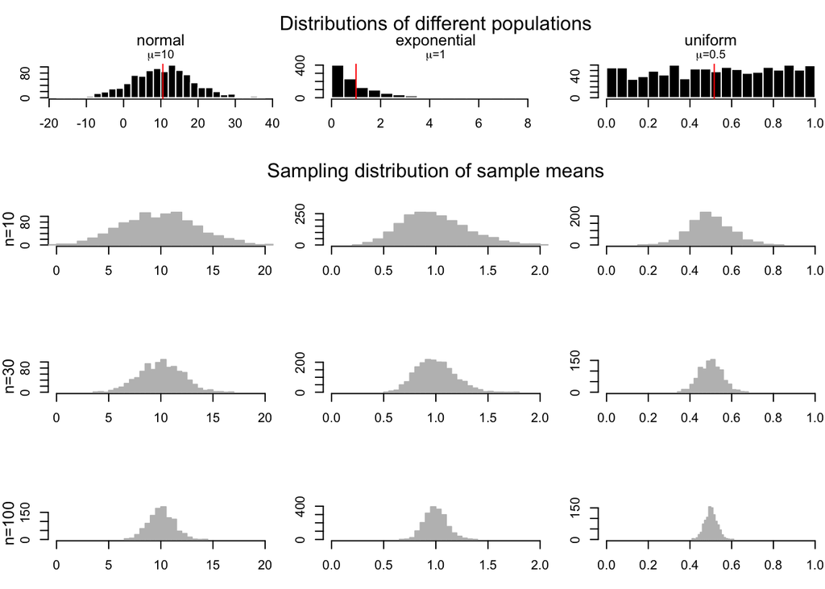

# 2 How to test for differences in samples

## 2.1

Test the difference of means of the following simulated genes using the randomization, t-test and `wilcox.test()` functions. Plot the distributions using histograms and boxplots.

```r
set.seed(101)
gene1=rnorm(30,mean=4,sd=3)
gene2=rnorm(30,mean=3,sd=3)
```

## 2.2

Test the difference of means of the following simulated genes using the randomization, t-test and `wilcox.test()` functions. Plot the distributions using histograms and boxplots.

```r
set.seed(100)
gene1=rnorm(30,mean=4,sd=2)
gene2=rnorm(30,mean=2,sd=2)
```

## 2.3

read the gene expression data set with `data=readRDS("StatisticsForGenomics/geneExpMat.rds")`. The data has 100 differentially expressed genes.First 3 columns are the test samples, and the last 3 are the control samples. Do a t-test for each gene (each row is a gene), record the p-values. Then, do a moderated t-test, as shown in the lecture notes and record the p-values. Do a p-value histogram and compare two approaches in terms of the number of significant tests with 0.05 threshold. On the p-values use FDR (BH), bonferroni and q-value adjustment methods. Calculate how many adjusted p-values are below 0.05 for each approach.

# 3 Relationship between variables: linear models and correlation

## 3.1

Below we are going to simulate X and Y values.

1. Run the code then fit a line to predict Y based on X.
2. Plot the scatter plot and the fitted line.
3. Calculate correlation and R^2.
4. Run the `summary()` function and try to extract P-values for the model from the object returned by `summary`. see `?summary.lm`
5. Plot the residuals vs fitted values plot, by calling `plot` function with `which=1` as the second argument. First argument is the model returned by `lm`.

```r
# set random number seed, so that the random numbers from the text
# is the same when you run the code.
set.seed(32)

# get 50 X values between 1 and 100
x = runif(50,1,100)

# set b0,b1 and varience (sigma)
b0 = 10
b1 = 2
sigma = 20
# simulate error terms from normal distribution
eps = rnorm(50,0,sigma)
# get y values from the linear equation and addition of error terms
y = b0 + b1*x+ eps
```

## 3.2

Read the data set histone modification data set with using a variation of: `df=readRDS("StatisticsForGenomics/HistoneModeVSgeneExp.rds")`. There are 3 columns in the data set these are measured levels of H3K4me3, H3K27me3 and gene expression per gene.

1. plot the scatter plot for H3K4me3 vs expression
2. plot the scatter plot for H3K27me3 vs expression
3. fit the model model for prediction of expression data using:
   - only H3K4me3 as explanatory variable
   - only H3K27me3 as explanatory variable
   - using both H3K4me3 and H3K27me3 as explanatory variables
4. inspect summary() function output in each case, which terms are significant
5. Is using H3K4me3 and H3K27me3 better than the model with only H3K4me3.
6. Plot H3k4me3 vs H3k27me3. Inspect the points that does not follow a linear trend. Are they clustered at certain segments of the plot. Bonus: Is there any biological or technical interpretation for those points ?